# Prediction Assignment

Daniel Lee

10/16/2016

## Introduction

We will using data from accelerometers on the belt, forearm, arm, and dumbell of 6 participants. They were asked to perform barbell lifts correctly and incorrectly in 5 different ways. Our objective is to use these data to predict the actions that they are performing.

The training data for this project are available [here](https://d396qusza40orc.cloudfront.net/predmachlearn/pml-training.csv)

The test data are available [here](https://d396qusza40orc.cloudfront.net/predmachlearn/pml-testing.csv)

More information of the data is available from the website [here](http://groupware.les.inf.puc-rio.br/har (see the section on the Weight Lifting Exercise Dataset).

## System Pre-requisite

1. The training data and testing data are stored in the RStudio current working director.
2. The packages in the below code chunk are required to produce this prediction model.

```r
require(data.table);require(dplyr);require(caret);require(ggplot2);require(corrplot);require(knitr);require(rmarkdown);require(randomForest)
```

## Data Cleaning and Exploratory

Lets perform some data exploration (training set) prior to any substantial model building activity.

After some preliminary study on the variables, we notice that there are some variables that should be excluded from the training set. We have excluded variables that represent the **statistics derived from other variables** and **related to time**.

```r
# load the training set into data table
dataset <- fread('pml-training.csv', sep= ',', row)
testingQuiz <- fread('pml-testing.csv', sep=',')
datasetDim <- dim(dataset)

print('The dimension of training set:')
```

```
## [1] "The dimension of training set:"
```

```r
datasetDim
```

```
## [1] 19622   160
```

```r
# remove variable V1 as its just the row number
dataset[, V1:=NULL]

# remove the statistics variables as there are derived from other variables within a specific time window
pattern = '(avg|var|kurtosis|skew|max|min|amplitude|std)'
statVar <- grep(pattern, colnames(dataset),ignore.case = T, value = T)
dataset[, (statVar):=NULL]

# remove the timestamp and window variables
pattern <- '(timestamp|window)'
timeVar <- grep(pattern, colnames(dataset), ignore.case = T, value = T)
dataset[, (timeVar):=NULL]

# change the target label to factor variable
dataset[, classe:=factor(classe)]

# print out the selected variable and its corresponding class
str(dataset)
```

```
## Classes 'data.table' and 'data.frame':   19622 obs. of  54 variables:
##  $ user_name           : chr  "carlitos" "carlitos" "carlitos" "carlitos" ...
##  $ roll_belt           : num  1.41 1.41 1.42 1.48 1.48 1.45 1.42 1.42 1.43 1.45 ...
##  $ pitch_belt          : num  8.07 8.07 8.07 8.05 8.07 8.06 8.09 8.13 8.16 8.17 ...
##  $ yaw_belt            : num  -94.4 -94.4 -94.4 -94.4 -94.4 -94.4 -94.4 -94.4 -94.4 -94.4 ...
##  $ total_accel_belt    : int  3 3 3 3 3 3 3 3 3 3 ...
##  $ gyros_belt_x        : num  0 0.02 0 0.02 0.02 0.02 0.02 0.02 0.02 0.03 ...
##  $ gyros_belt_y        : num  0 0 0 0 0.02 0 0 0 0 0 ...
##  $ gyros_belt_z        : num  -0.02 -0.02 -0.02 -0.03 -0.02 -0.02 -0.02 -0.02 -0.02 0 ...
##  $ accel_belt_x        : int  -21 -22 -20 -22 -21 -21 -22 -22 -20 -21 ...
##  $ accel_belt_y        : int  4 4 5 3 2 4 3 4 2 4 ...
##  $ accel_belt_z        : int  22 22 23 21 24 21 21 21 24 22 ...
##  $ magnet_belt_x       : int  -3 -7 -2 -6 -6 0 -4 -2 1 -3 ...
##  $ magnet_belt_y       : int  599 608 600 604 600 603 599 603 602 609 ...
##  $ magnet_belt_z       : int  -313 -311 -305 -310 -302 -312 -311 -313 -312 -308 ...
```

[output cut: 41 more lines]

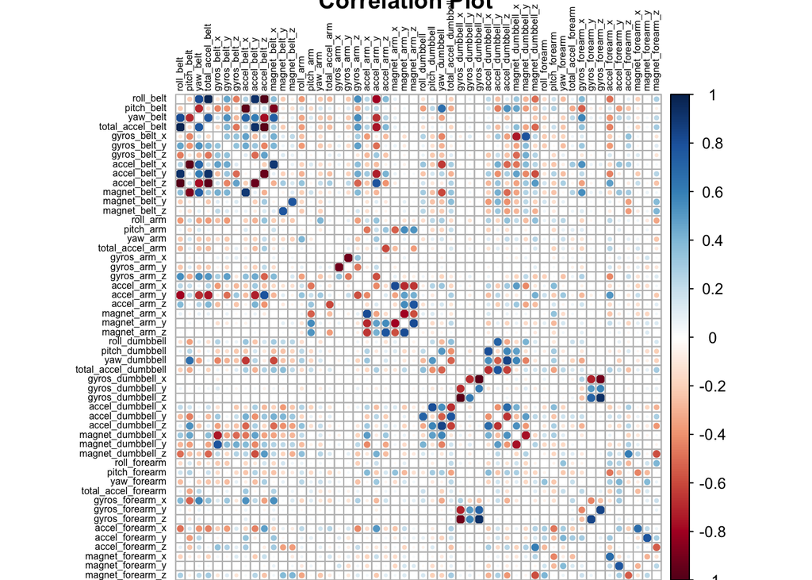

```r
# Correlation plot
corMatrix <- cor(dplyr::select(dataset, -classe, -user_name))
corrplot(corMatrix, add =F, diag = F, tl.cex = .5, tl.col = 'black', title = 'Correlation Plot')
```

```r
# target label

targetTable <- table(dataset[, classe]) %>% prop.table() %>% data.table
setnames(targetTable, c('V1','N'),c('Class', 'Proportion'))
targetTable
```

```
##    Class Proportion
## 1:     A  0.2843747
## 2:     B  0.1935073
## 3:     C  0.1743961
## 4:     D  0.1638977
## 5:     E  0.1838243
```

```r
kable(targetTable, caption = 'Proportion of Label Class in Training Set')
```

Proportion of Label Class in Training Set

| Class | Proportion |
| --- | --- |
| A | 0.2843747 |
| B | 0.1935073 |
| C | 0.1743961 |
| D | 0.1638977 |
| E | 0.1838243 |

After removing those unnecessary variables, the retained variables are all related to human motion in different axis. From the correlation plot above, we observe that some of these body motion variables do exhibit significant correlation on each other. As multi-colinearity is not a big issue to the model that we will use, we shall not investigate further.

Besides that, the **distribution of each class** in the dataset are quite **balance**, hence we do not have to worry about imbalance class issue.

## Model Building

### Data Splitting

We are ready to build the prediction model with dataset that we have cleaned **(52 predictors + 1 target label)**. The dataset will be splitted into **training sets and validation sets** with the proportion of **60% and 40%**. Note that the training set will be further partitioned into training and validation during parameter tuning which is transparent to us.

```r
# split the data into training and validation set
set.seed(123)
intrain <- createDataPartition(dataset$classe, p = .6, list = F)
training <- dataset[intrain,]
validation <- dataset[-intrain,]
```

### Model Building

We shall use random forest to build the prediction model. We leave the most of the parameters as default except that the **ntree parameter is set to be 50**. This means that only 50 trees will be developed in the model.

The training error seems to be low but we will use the validation set as our reference on prediction error.

```r
# set up the train control and build the model
set.seed(124)
fit.rf <- randomForest(x = select(training, -user_name, -classe), y = training$classe, ntree = 50, na.action = na.pass, importance = T)

print('Summary of the fitted model:')
```

```
## [1] "Summary of the fitted model:"
```

```r
fit.rf
```

```
##
## Call:
##  randomForest(x = select(training, -user_name, -classe), y = training$classe,      ntree = 50, importance = T, na.action = na.pass)
##                Type of random forest: classification
##                      Number of trees: 50
## No. of variables tried at each split: 7
##
##         OOB estimate of  error rate: 1%
## Confusion matrix:
##      A    B    C    D    E class.error
## A 3342    5    0    0    1 0.001792115
## B   21 2246   10    0    2 0.014480035
## C    1   19 2023   11    0 0.015092502
## D    1    1   34 1892    2 0.019689119
## E    0    2    2    6 2155 0.004618938
```

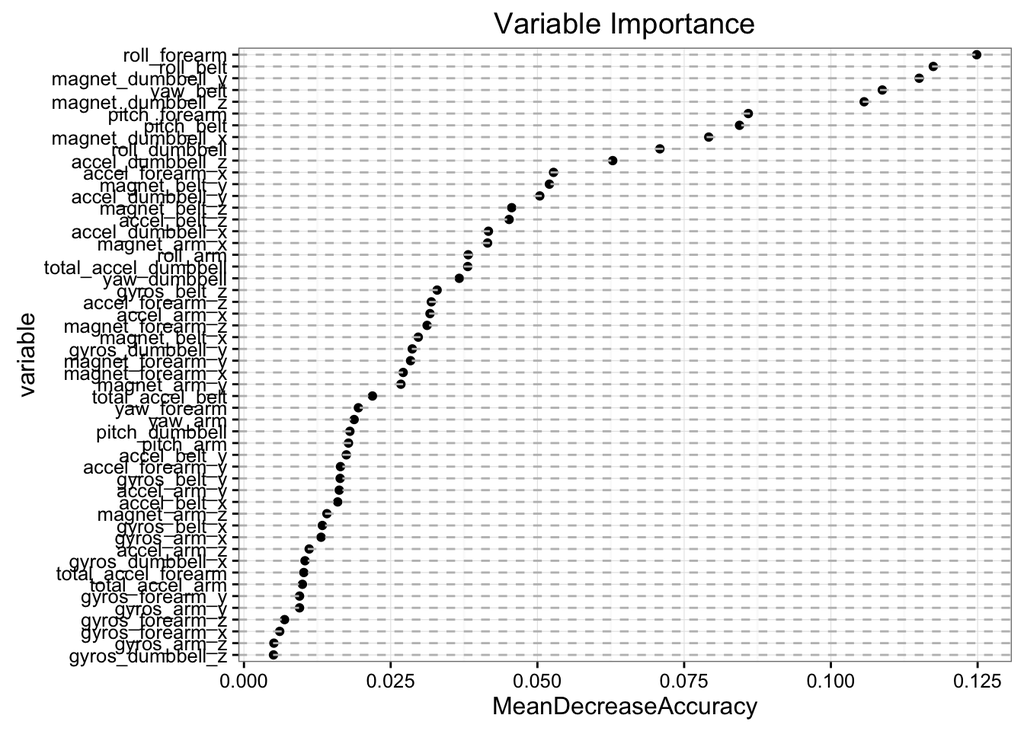

```r
# plot the variable importance
fitImp <- fit.rf$importance

fitImp <- data.table(variable = factor(rownames(fitImp)), MeanDecreaseAccuracy = fitImp[, 'MeanDecreaseAccuracy'])
fitImp[, variable:=reorder(variable, MeanDecreaseAccuracy)]

ggplot(fitImp) +  geom_point(aes(x = MeanDecreaseAccuracy, y = variable))+ geom_hline(aes(yintercept = as.numeric(variable)), linetype = 2, color = 'grey')  + theme_bw() + labs(title = 'Variable Importance')
```

### Model Validation

From the confusion matrix below, the prediction model seems to be working well and able to classify the label correctly with the error of less than 1%.

```r
# generate prediction on validation set and its confusion matrix
pred.validation <- predict(fit.rf, validation, na.action = na.pass)

confusionMatrix(pred.validation, validation$classe)
```

```
## Confusion Matrix and Statistics
##
##           Reference
## Prediction    A    B    C    D    E
##          A 2228    9    0    0    0
##          B    3 1507   16    0    0
##          C    0    2 1351   18    4
##          D    0    0    1 1268    5
##          E    1    0    0    0 1433
##
## Overall Statistics
##
##                Accuracy : 0.9925
##                  95% CI : (0.9903, 0.9943)
##     No Information Rate : 0.2845
##     P-Value [Acc > NIR] : < 2.2e-16
##
##                   Kappa : 0.9905
##  Mcnemar's Test P-Value : NA
##
## Statistics by Class:
##
##                      Class: A Class: B Class: C Class: D Class: E
## Sensitivity            0.9982   0.9928   0.9876   0.9860   0.9938
## Specificity            0.9984   0.9970   0.9963   0.9991   0.9998
## Pos Pred Value         0.9960   0.9875   0.9825   0.9953   0.9993
## Neg Pred Value         0.9993   0.9983   0.9974   0.9973   0.9986
## Prevalence             0.2845   0.1935   0.1744   0.1639   0.1838
## Detection Rate         0.2840   0.1921   0.1722   0.1616   0.1826
## Detection Prevalence   0.2851   0.1945   0.1752   0.1624   0.1828
## Balanced Accuracy      0.9983   0.9949   0.9919   0.9925   0.9968
```

## Generate Prediction on Testing Set

We will now generate the prediction for the testing set. Note that the testing test does not contain the true classe label. The performance of this prediction will be evaluated as part of the quiz.

```r
colname <- c(colnames(dplyr::select(training, -classe)), 'problem_id')
testing <- testingQuiz[, .SD, .SDcols = colname]
pred.testing <- predict(fit.rf, testing, na.action = na.pass)
testing[, predicted_classe:=pred.testing]
write.csv(testing, 'quiz_result.csv')
```